# Businness Understanding - V1

Diana Archila Cordero

2023-08-24

Se busca estimar la reserva de dinero que deben tener las empresas de seguros en los Estados Unidos, a partir de la información de siniestros reportados entre los años 1988 y 1997, y la información de los pagos realizados por las aseguradoras en el año del siniestro y hasta 10 años después. Para poder realizar la estimación de la reserva que deben tener las compañías de seguros, se hace necesario entender cómo funciona el proceso de reclamaciones, de las compañías aseguradores y qué factores y roles interfieren en el proceso.

# 1. Contexto Industria Aseguradora:

Las compañías de seguros se encargan de proporcionar dinero a individuos o grupos en caso de que estos se vean afectados por determinados eventos, bajo condiciones y circunstancias pactadas desde el comienzo del contrato; cubriendo ciertos riesgos económicos que puedan en alguna medida compensar los daños causados. La operación de esta industria se da mediante la acumulación de dinero obtenidos del pago que realizan los asegurados expuestos a la posible ocurrencia de ciertos riesgos, durante un determinado periodo de tiempo y cuotas definidas. De esta manera, se puede respaldar a los pocos que se vean involucrados en la ocurrencia de siniestros.

Cuando se reporta un siniestro, la aseguradora debe iniciar el proceso de indemnización que le corresponda a la persona afectada, según las condiciones y garantías acordadas en la firma de la póliza. De forma general, según lo descrito por Gallo (Gallo, 2017), el proceso de indemnizaciones se da como se muestra en el esquema de la Figura 1.

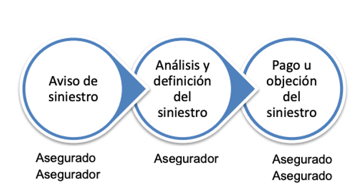

*Figura 1. Pasos del proceso de indemnizaciones.*

## 1.1. Actores que intervienen en el proceso

En el proceso de obtención de una póliza de seguro se tienen 4 roles identificables, de manera que se definen las acciones que tendrá cada uno a partir de la firma de la póliza el seguro. Como se muestra en la Figura 2, al firmar un contrato de seguro, no están solo la aseguradora y el asegurado, sino en algunos casos, un tercero puede comprar el seguro, pero no para beneficio propio sino de otra persona, quien en caso de ocurrencia de un evento de afectación, será beneficiado con la indemnización correspondiente.

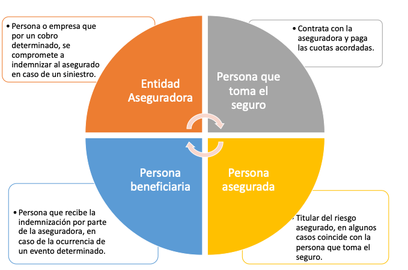

*Figura 2. Partes que intervienen en un contrato de póliza de seguro.*

# 2. Compilación de antecedentes

Para poder plantear un plan de desarrollo para la estimación de las reservas de dinero que debe tener una compañía aseguradora, previendo la reclamación de pagos. Es necesario conocer cierta información del funcionamiento y estructura interna en cuanto a personal, recursos y partes interesadas que pueden verse beneficiados por el proyecto.

## 2.1. Estructura organizacional

Como referente de los cargos, áreas y subprocesos que se llevan a cabo dentro de una empresa de seguros, se va a tener en cuenta la información publicada por la aseguradora Positiva. A continuación se muestra el organigrama de la compañía aseguradora, dentro de las áreas y cargos relevantes, para el proyecto de minería de datos, se puede decir que serán claves los siguientes:

- **Oficina de Tecnología de la Información:** Será clave en la recolección y entendimiento de los datos, este equipo tiene conocimiento de como se encuentran estructuradas las bases, algunos de los casos que pueden encontrarse como contaminación de los datos, versiones recientes, conexión y esquemas de la base, que serán de utilidad para poder determinar la calidad de los datos.
- **Gerencia de Actuaria y Reaseguros:** Desde esta gerencia, se podrá tener en cuenta la opinión experta respecto a los riesgos, càlculos y factores tenidos en cuenta a la hora de fijar el valor del retroactivo que se le ofrece al asegurado.
- **Gerencia de Indemnizaciones:** Este departamento podrá proveer la información y análisis de las estadísticas y datos históricos de las indemnizaciones que se han pagado. Asimismo, tendrá datos relevantes como el monto que se desembolsa en cierto periodo de tiempo por cada tipo de póliza que maneja la compañía.
- **Gerencia Investigación y Control de Riesgo:** Es posiblemente la gerencia a la cual se puede estar beneficiando directamente con el proyecto actual, debido a que el modelo de estimación que se plantea realizar, permite tener una perspectiva de la reserva que debe tener la compañía para apalancar los siniestros en que se ven involucrados de los asegurados.

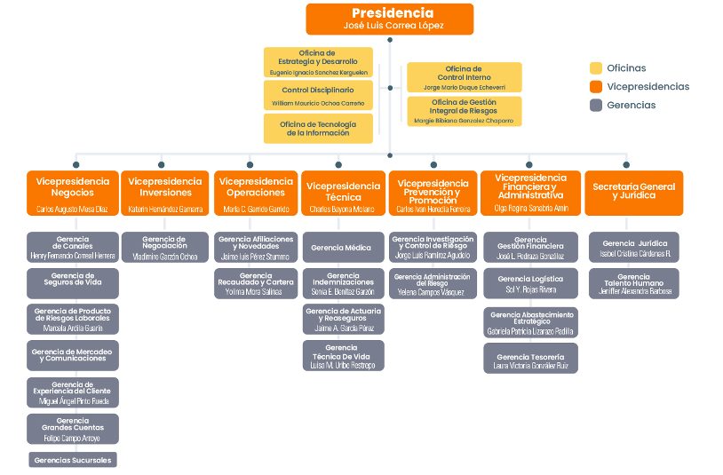

*Figura 3. Organigrama Positiva.*

## 2.2. Área de mayor relevancia

El desarrollo del proyecto, impactaría directamente la vertical de **Prevención y Promoción**

## 2.3. Tratamiento actual de la problemática